Skip to content

Full ProfessorStructural Mechanics & Acoustics

# Mathieu Aucejo

I develop methods to identify, model and control vibrations and sound in mechanical structures, alongside open-source tools for research and education.

[MACS](https://www.macs.cnam.fr/) Conservatoire national des arts et métiers Paris, France

Explore my research → Get in touch

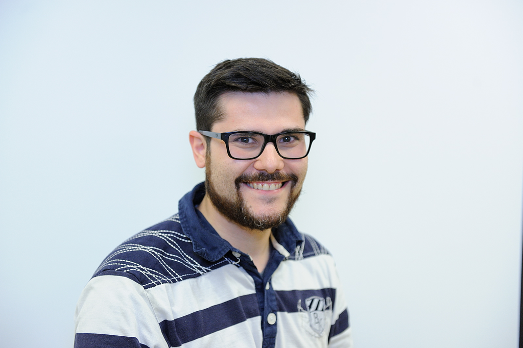

**Journal articles**

34

**Conference papers**

47

**Years in research**

15+

**Open-source packages**

8

About

## Welcome!

I am a full professor of Structural Mechanics and Acoustics at the Laboratoire de Mécanique, Acoustique, Contrôle et Calcul Scientifique ([MACS](https://www.macs.cnam.fr/)) of [Le Cnam](https://www.cnam.fr/) in Paris.

I am an enthusiastic and avid user of the Typst

[figure not shown]

markup language and the Julia

[figure not shown]

programming language. I turn a good part of my research and teaching material into open-source tools.

Research

## Research interests

Identification

### Inverse problems

Estimating unknown excitation sources from vibration measurements with Bayesian methods.

→

Control

### Vibration control

Reducing structural vibrations and noise through passive and active strategies.

→

Modelling

### Vibro-acoustic modeling

Predicting how structures vibrate and radiate sound, from analytical models to numerical simulation.

→

Publications

## Recent work

1. 2027

   Journal article

   [An adaptive frequency-domain Kalman filter for source identification in structural dynamics](https://doi.org/10.1016/j.jsv.2026.120170)

   **Mathieu Aucejo** and O. de Smet

   Journal of Sound and Vibration, vol. 647, p. 120170

   [DOI](https://doi.org/10.1016/j.jsv.2026.120170)[HAL](https://hal.science/hal-05798703v1)[PDF](https://hal.science/hal-05798703/document)[0](https://openalex.org/works?filter=cites:W7220987863)
2. 2026

   Journal article

   [Evaluation of markerless motion capture to compute center of mass trajectory in artistic gymnastics](https://doi.org/10.46298/mbj.19217)

   Suzon Pucheu, Diane Haering, **Mathieu Aucejo** and Charles Pontonnier

   [DOI](https://doi.org/10.46298/mbj.19217)[HAL](https://inria.hal.science/hal-05671132v2)[PDF](https://inria.hal.science/hal-05671132/document)[0](https://openalex.org/works?filter=cites:W7166919842)
3. 2025

   Journal article

   [A frequency-domain sequential Bayesian filter for sparse and broadband force estimation problems](https://doi.org/10.1016/j.ymssp.2025.112729)

   **Mathieu Aucejo** and Olivier de Smet

   Mechanical Systems and Signal Processing, vol. 232, p. 112729

   [DOI](https://doi.org/10.1016/j.ymssp.2025.112729)[HAL](https://hal.science/hal-05038580v2)[PDF](https://hal.science/hal-05038580/document)[4](https://openalex.org/works?filter=cites:W4409528711)
4. 2025

   Journal article

   [Prediction of impactor acceleration when impacting a gymnastics mat using neural networks](https://doi.org/10.46298/mbj.16196)

   Suzon Pucheu, Diane Haering, **Mathieu Aucejo** and Charles Pontonnier

   Multidisciplinary Biomechanics Journal, vol. 2, p. 485–487

   [DOI](https://doi.org/10.46298/mbj.16196)[HAL](https://hal.science/hal-05191749v2)[PDF](https://hal.science/hal-05191749/document)[0](https://openalex.org/works?filter=cites:W4415249298)

All publications →

Blog

## Latest posts

Tutorial

[figure not shown]

### Make beautiful apps with Makie

Develop interactive apps to share your ideas

Mathieu Aucejo · 13 November 2026

→

All posts →

Background

## Education

1. 2019

   Habilitation to supervise research (HDR)

   Conservatoire national des arts et métiers, France
2. 2010

   PhD in Acoustics

   INSA Lyon, France
3. 2007

   MSc in Acoustics

   INSA Lyon, France
4. 2007

   MEng in Mechanical Engineering

   INSA Lyon, France

Contact

## Let’s talk

Interested in a collaboration, a PhD or internship position, or one of my software packages? Feel free to reach out.

mathieu.aucejo@lecnam.net